# Table of Contents

```python
import os
import numpy as np
import pandas as pd
from scipy import stats
import matplotlib.pyplot as plt
import seaborn as sns

plt.rcParams['font.sans-serif']=['SimHei'] #用来正常显示中文标签
plt.rcParams['axes.unicode_minus']=False #用来正常显示负号
os.chdir(r"F:\Diverse\statistics\Python_data_analysis\2018_data")
%matplotlib inline
```

### 数据集导入

```python
data_org = pd.read_csv(r"ROP_data/mud1mud2final.csv",encoding="GBK")
print("data_org shape: ",data_org.shape)
```

```
data_org shape:  (5095, 17)
```

```python
data_org.head(2)
```

|  | depth | 密度 | 粘度 | PV | YP | 初切 | 终切 | 滤失量 | 氯根含量 | 钙离子含量 | 钻头尺寸 | 钻压 | 转速 | 排量 | 泵压 | ROP | CODE |
| --- | --- | --- | --- | --- | --- | --- | --- | --- | --- | --- | --- | --- | --- | --- | --- | --- | --- |
| 0 | 58.46 | 1.06 | 115 | 28.0 | 12.5 | 5.0 | 16.0 | 8.0 | 770 | 20.0 | 660.4 | 40 | 40.0 | 32 | 1.0 | 3.44 | 67 |
| 1 | 84.00 | 1.06 | 120 | 30.0 | 11.0 | 5.0 | 16.0 | 8.0 | 800 | 20.0 | 660.4 | 70 | 55.0 | 45 | 1.0 | 1.39 | 67 |

### 探索性数据分析

```python
data_org.columns
```

```
Index(['depth', '密度', '粘度', 'PV', 'YP', '初切', '终切', '滤失量', '氯根含量', '钙离子含量',
       '钻头尺寸', '钻压', '转速', '排量', '泵压', 'ROP', 'CODE'],
      dtype='object')
```

```python
data_org.info()
```

```
<class 'pandas.core.frame.DataFrame'>
RangeIndex: 5095 entries, 0 to 5094
Data columns (total 17 columns):
depth    5095 non-null float64
密度       5095 non-null float64
粘度       5095 non-null int64
PV       5095 non-null float64
YP       5095 non-null float64
初切       5095 non-null float64
终切       5095 non-null float64
滤失量      5095 non-null float64
氯根含量     5095 non-null int64
钙离子含量    5095 non-null float64
钻头尺寸     5095 non-null float64
钻压       5095 non-null int64
转速       5095 non-null float64
排量       5095 non-null int64
泵压       5095 non-null float64
ROP      5095 non-null float64
CODE     5095 non-null int64
dtypes: float64(12), int64(5)
memory usage: 676.8 KB
```

```python
data_org.describe()
```

|  | depth | 密度 | 粘度 | PV | YP | 初切 | 终切 | 滤失量 | 氯根含量 | 钙离子含量 | 钻头尺寸 | 钻压 | 转速 | 排量 | 泵压 | ROP | CODE |
| --- | --- | --- | --- | --- | --- | --- | --- | --- | --- | --- | --- | --- | --- | --- | --- | --- | --- |
| count | 5095.000000 | 5095.000000 | 5095.000000 | 5095.000000 | 5095.000000 | 5095.000000 | 5095.000000 | 5095.000000 | 5095.000000 | 5095.000000 | 5095.000000 | 5095.000000 | 5095.000000 | 5095.000000 | 5095.000000 | 5095.000000 | 5095.00000 |
| mean | 4232.466296 | 1.727933 | 64.377233 | 37.127753 | 11.701668 | 3.477429 | 13.590893 | 3.523886 | 59648.134642 | 296.869213 | 365.891588 | 110.190972 | 90.694897 | 41.186065 | 19.612744 | 2.034502 | 42.35054 |
| std | 1927.011002 | 0.313083 | 13.531224 | 17.354372 | 4.398264 | 1.806978 | 5.761600 | 2.363249 | 48843.162262 | 296.203662 | 114.022640 | 51.951654 | 19.175317 | 12.237520 | 5.767528 | 2.501400 | 25.08438 |
| min | 20.000000 | 1.050000 | 35.000000 | 1.000000 | -10.000000 | 0.500000 | 2.000000 | 0.100000 | 0.000000 | 0.000000 | 101.600000 | 0.000000 | 0.000000 | 7.000000 | 0.000000 | 0.060000 | 0.00000 |
| 25% | 3116.000000 | 1.600000 | 55.000000 | 25.000000 | 9.000000 | 2.000000 | 9.000000 | 2.000000 | 31700.000000 | 120.000000 | 333.380000 | 80.000000 | 80.000000 | 37.000000 | 19.000000 | 0.730000 | 21.00000 |
| 50% | 4417.000000 | 1.700000 | 62.000000 | 35.000000 | 11.000000 | 3.000000 | 13.000000 | 2.800000 | 49000.000000 | 220.000000 | 333.400000 | 120.000000 | 90.000000 | 43.000000 | 21.000000 | 1.280000 | 42.00000 |
| 75% | 5808.500000 | 1.890000 | 71.000000 | 46.000000 | 14.000000 | 4.500000 | 17.000000 | 4.200000 | 69824.500000 | 380.000000 | 444.500000 | 150.000000 | 100.000000 | 50.000000 | 23.000000 | 2.215000 | 67.00000 |
| max | 7360.000000 | 2.550000 | 154.000000 | 127.000000 | 49.000000 | 15.000000 | 40.000000 | 22.000000 | 199000.000000 | 2200.000000 | 762.000000 | 260.000000 | 140.000000 | 73.000000 | 42.000000 | 26.500000 | 85.00000 |

#### 检验数据分布正态性

```python
def exploration_data(data):
    row = data.shape[1]
    col = 2
    #plt.subplots_adjust(hspace=0.3,wspace=0.5)
    for i in range(row):
        fig, axes = plt.subplots(nrows=1,ncols=2,figsize=(6,3))
        tmp = data.iloc[:,i]
        sns.distplot(tmp,ax=axes[0])
        stats.probplot(tmp,plot=axes[1])
        fig.tight_layout()
```

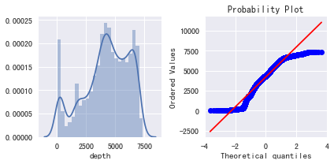

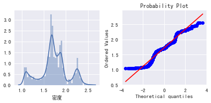

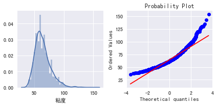

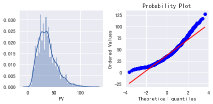

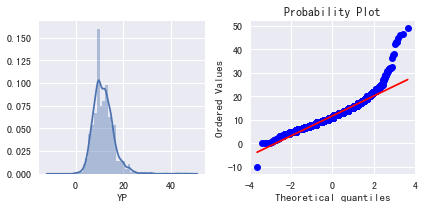

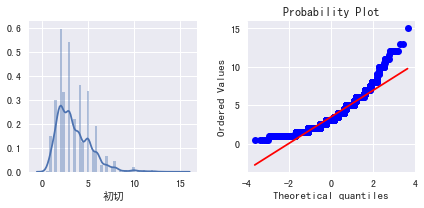

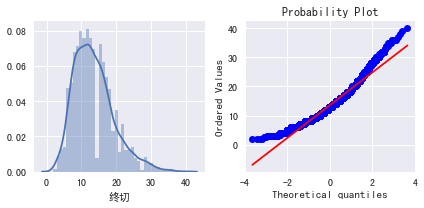

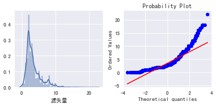

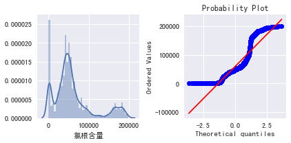

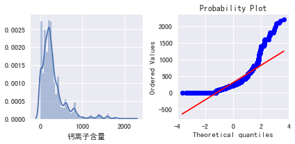

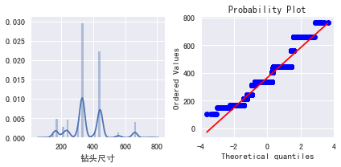

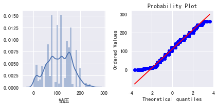

[5 more figures not shown]

```python
exploration_data(data_org)
```

- ROP明显右偏，可取log
- 钻压、转速为离散取值？
- 钻头尺寸可作为分类变量
- 氯根、钙离子变量中，0值过多
- 数量级差异大的数据，可取log，减缓波动
- 继续探索变量：钻压、转速、氯根、钙离子、泵压、滤失量

#### 二次探索变量

##### 钻压

```python
WOB = data_org[["depth","钻压"]]
```

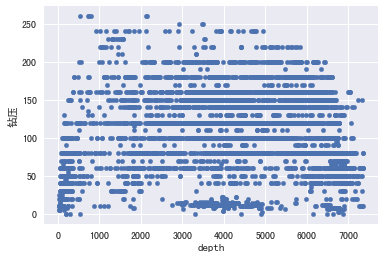

```python
WOB.plot(kind="scatter",x="depth",y="钻压")
```

```python
WOB[WOB["钻压"] == 0]
```

|  | depth | 钻压 |
| --- | --- | --- |
| 203 | 6870.00 | 0 |
| 224 | 206.00 | 0 |
| 234 | 3307.00 | 0 |
| 327 | 6624.30 | 0 |
| 789 | 534.00 | 0 |
| 1715 | 6486.17 | 0 |
| 4423 | 6147.45 | 0 |
| 4484 | 201.30 | 0 |
| 4507 | 4406.00 | 0 |
| 4720 | 299.80 | 0 |
| 4951 | 4898.00 | 0 |

##### 转速

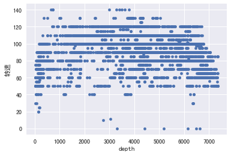

```python
RPM = data_org[["depth","转速"]]
RPM.plot(kind="scatter",x="depth",y="转速")
```

```python
RPM[RPM["转速"] == 0]
```

|  | depth | 转速 |
| --- | --- | --- |
| 234 | 3307.00 | 0.0 |
| 327 | 6624.30 | 0.0 |
| 1715 | 6486.17 | 0.0 |
| 3847 | 5198.00 | 0.0 |
| 4423 | 6147.45 | 0.0 |
| 4507 | 4406.00 | 0.0 |

##### 氯根含量

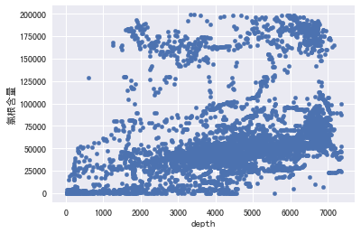

```python
CL = data_org[["depth","氯根含量"]]
CL.plot(kind="scatter",x="depth",y="氯根含量")
```

```python
CL[CL["氯根含量"]==0].shape
```

```
(168, 2)
```

##### 钙离子含量

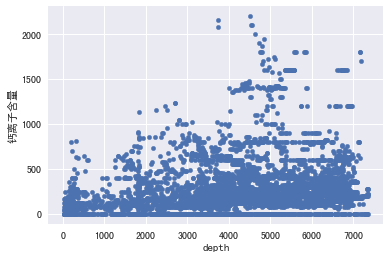

```python
CA = data_org[["depth","钙离子含量"]]
CA.plot(kind="scatter",x="depth",y="钙离子含量")
```

```python
CA[CA["钙离子含量"]==0].shape
```

```
(555, 2)
```

##### 泵压

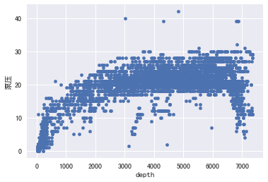

```python
Pump = data_org[["depth","泵压"]]
Pump.plot(kind="scatter",x="depth",y="泵压")
```

##### 滤失量

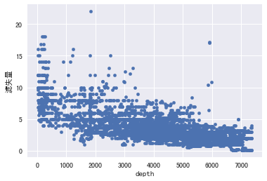

```python
LU = data_org[["depth","滤失量"]]
LU.plot(kind="scatter",x="depth",y="滤失量")
```

#### 探究变量相关性

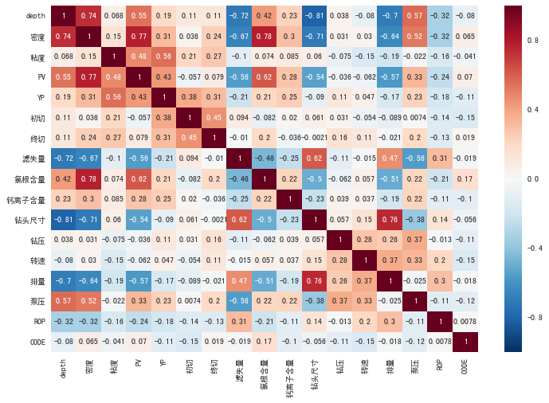

```python
corr = data_org.corr()
fig = plt.figure(figsize=(12,8))
ax = fig.add_subplot()
ax = sns.heatmap(corr,annot=True,ax=ax)
```

#### 数据清洗

- 去除浅层数据样本 <=1500
- 去除YP负值样本
- 去除离子含量列
- 去除数量少的低转速<20、低钻压样本<5
- 去除code列

```python
data = data_org.drop(labels=["氯根含量","钙离子含量","CODE"],axis=1)
data = data[data.YP > 0]
data = data[data.depth >= 1500]
data = data[data["钻压"]>=5]
data = data[data["转速"]>=20]
data = data[data["泵压"]<=35]
data = data[data["滤失量"]<=20]
```

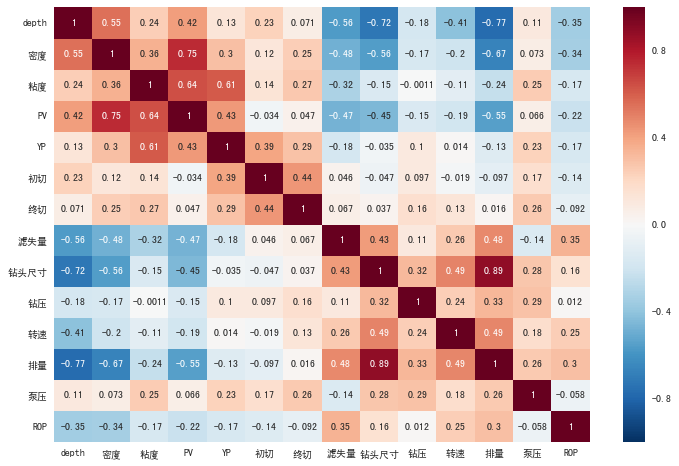

```python
corr = data.corr()
fig = plt.figure(figsize=(12,8))
ax = fig.add_subplot()
sns.heatmap(corr,annot=True,ax=ax)
```

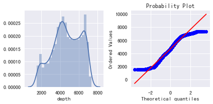

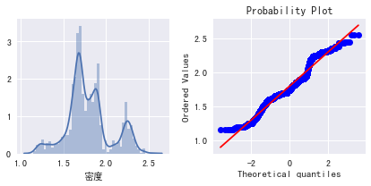

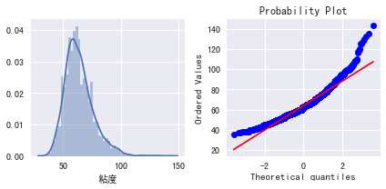

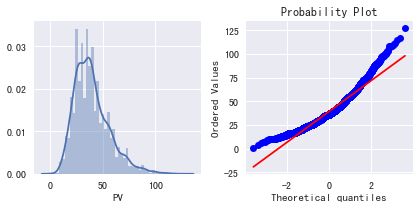

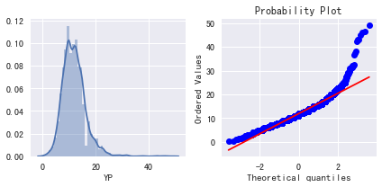

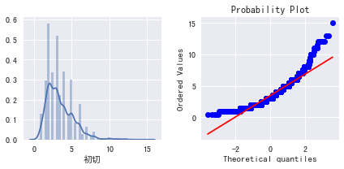

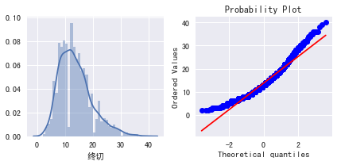

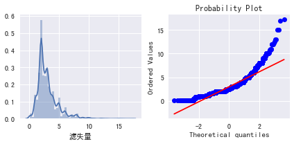

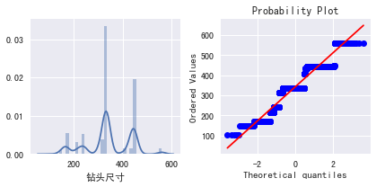

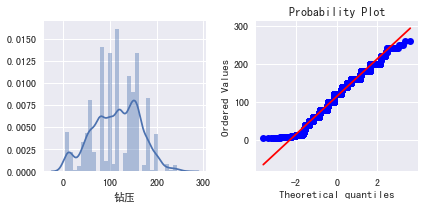

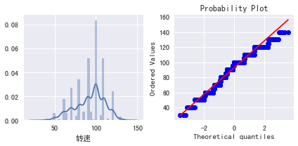

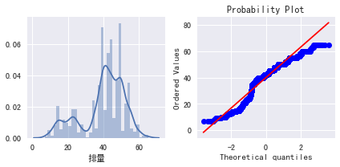

[2 more figures not shown]

```python
exploration_data(data)
```

data.to_csv(r"ROP_data/train.csv",index=False)